# Aufgaben

## Aufgaben

#### Aufgabe

1. Laden Sie den Datensatz `affairs`:

   ```
   affairs_path <- "https://vincentarelbundock.github.io/Rdatasets/csv/AER/Affairs.csv"
   ```

   ```
   affairs <- read_csv(affairs_path)
   ```

   Lesen Sie das *Data Dictionnary* [hier](https://vincentarelbundock.github.io/Rdatasets/doc/AER/Affairs.html).

   Wir definieren als “Halodrie” eine Person mit mindestens einer Affäre (laut Datensatz).

   Bearbeiten Sie folgende Aufgaben:
   1. Filtern Sie mal nach Halodries!
   2. Sortieren Sie (absteigend) nach Anzahl der Affären!
   3. Wählen Sie die Spalten zu Anzahl der Affären, ob es Kinder in der Ehe gibt und die Zufriedenheit mit der Ehe. Dann sortieren Sie dann nach Anzahl der Kinder und *danach* nach der Anzahl der Affären.
   4. Berechnen Sie die mittlere Anzahl der Affären!
   5. Berechnen Sie die mittlere Anzahl der Affären pro Geschlecht und aufgeteilt auf Partnerschaften mit bzw. ohne Kinder.
   6. Geben Sie für jede Person die höhere der zwei Zahlen von Religiösität und Ehezufriedenheit aus!
   7. Berechnen Sie jeweils das Heiratsalter!

#### Aufgabe

2. Importieren Sie den folgenden Datensatz in R:

   ```
   mtcars <- read_csv("https://vincentarelbundock.github.io/Rdatasets/csv/datasets/mtcars.csv")
   ```

   Übersetzen Sie dann die folgende R-Sequenz ins Deutsche:

   ```
   mtcars %>%
     drop_na() %>%
     select(mpg, hp, cyl) %>%
     filter(hp > 100, cyl >= 6) %>%
     group_by(cyl) %>%
     summarise(mpg_mean = mean(mpg))
   ```

   ```
   ## # A tibble: 2 × 2
   ##     cyl mpg_mean
   ##   <dbl>    <dbl>
   ## 1     6     19.7
   ## 2     8     15.1
   ```

#### Aufgabe

3. Welcher Kennwert ist robust (gegenüber Extremwerten)?
   1. Standardabweichung
   2. Mittelwert
   3. Korrelation
   4. Median
   5. Maximalwert

#### Aufgabe

4. Welcher Kennwert ist robust (gegenüber Extremwerten)?
   1. Schiefe
   2. Regressionsgewicht
   3. Summe
   4. Korrelation
   5. Interquartilsabstand

#### Aufgabe

5. Berechnen Sie den *Median* der folgenden Datenreihe!

   *Hinweis*: Runden Sie auf zwei Dezimalstellen. Beachten Sie, dass das Dezimalzeichen (Punkt oder Komma) je nach Ihrem System unterschiedlich sein kann.

   ```
   ## [1] 2.77 0.01 5.11 0.14 0.65
   ```

#### Aufgabe

6. Berechnen Sie den *Mittelwert* der folgenden Datenreihe!

   *Hinweis*: Runden Sie auf zwei Dezimalstellen. Beachten Sie, dass das Dezimalzeichen (Punkt oder Komma) je nach Ihrem System unterschiedlich sein kann.

   ```
   ## [1] 7.10 2.46 3.90 0.91 9.62
   ```

#### Aufgabe

7. Berechnen Sie den Mittelwert folgender Zahlenreihe; ignorieren sie etwaige fehlende Werte. Runden Sie auf zwei Dezimalstellen.

   ```
   ## [1] -1.02 -0.08 -0.23 -0.82  0.77    NA
   ```

#### Aufgabe

8. Betrachten Sie die Histogramme.

   Wählen Sie das Histogramm, welches am deutlichsten die Eigenschaft “symmetrisch” aufweist!

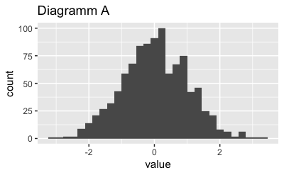

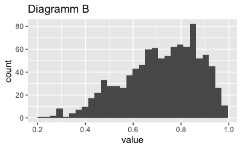

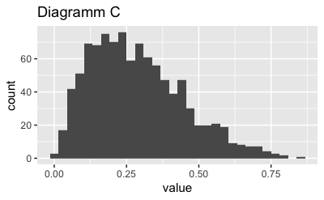

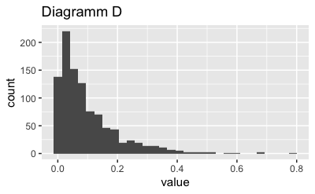

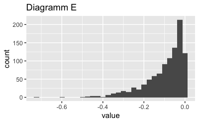

   1. A
   2. B
   3. C
   4. D
   5. E

#### Aufgabe

9. Betrachten Sie die Histogramme.

   Wählen Sie das Histogramm, welches am deutlichsten folgende Eigenschaft aufweist:

   $MW < Md$

   *Hinweis*: $MW$ steht für *Mittelwert* und $Md$ steht für *Median*.

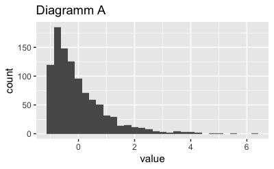

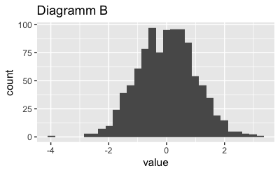

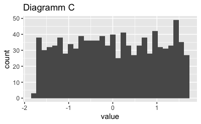

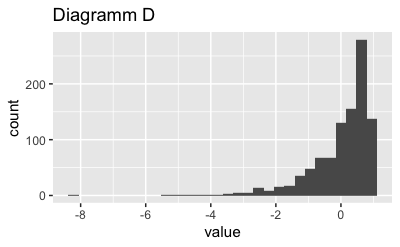

   1. A
   2. B
   3. C
   4. D

#### Aufgabe

10. Welche Form der Verteilung liegt wohl (am ehesten) für die Variable `Geburten je Tag im Monat` vor?
    1. linksschief
    2. normalverteilt
    3. rechtsschief
    4. gleichverteilt

#### Aufgabe

11. Sei $X \sim \mathcal{N}(42, 7)$ und $x_1 = 28$.

    Berechnen Sie den z-Wert für $x_1$!

    Hinweis:
    - Runden Sie ggf. auf die nächste ganze Zahl.

#### Aufgabe

12. Welches der folgenden Diagramm hat die größte Streuung, gemessen in Standardabweichung?

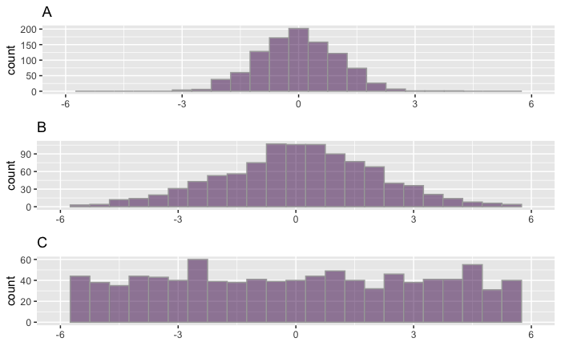

    1. A
    2. B
    3. C
    4. alle gleich
    5. keine Antwort möglich

#### Aufgabe

13. Wählen Sie das Diagramm, in dem der vertikale gestrichelte Linie am genauesten die Position des Medians ($Md$) widerspiegelt.

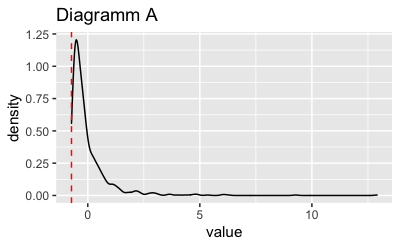

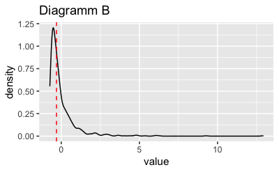

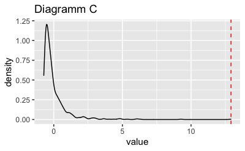

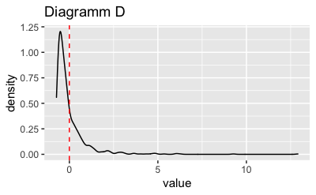

    1. A
    2. B
    3. C
    4. D

#### Aufgabe

14. Für welche Abbildung gilt, dass der Median kleiner ist als der (zugehörige) arithmetischer Mittelwert?

    Anders gesagt, gesucht ist $md < \bar{x}$

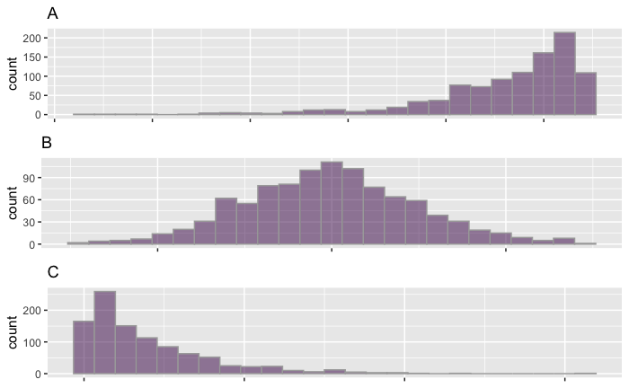

    1. A
    2. B
    3. C
    4. keine Antwort möglich